# In-Class Session 2: Linear Regression

Econometrics I

This notebook reproduces the simulations from Lecture 2 and leaves you two short problems.

# Reproduce: the multivariate normal and the regression line

The lecture derived the regression function from the bivariate normal. Simulate it:

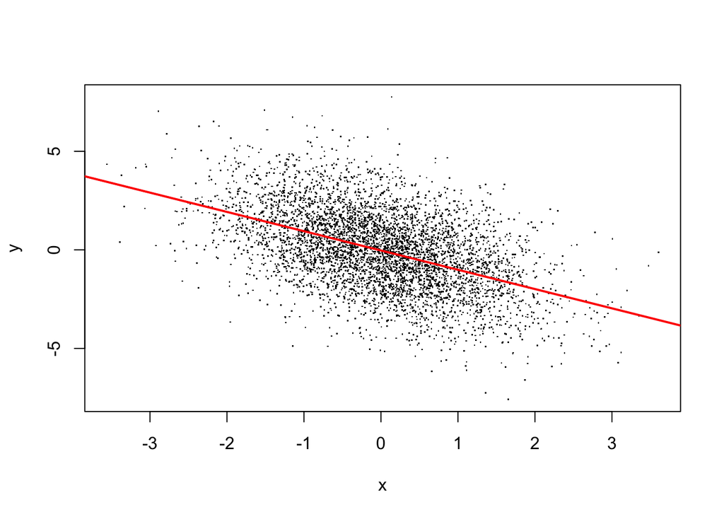

```r
mu <- c(0, 0)
Sigma <- matrix(c(4, -1, -1, 1), 2, 2)
yx <- mvrnorm(5000, mu, Sigma)
plot(yx[, 2], yx[, 1], pch = ".", xlab = "x", ylab = "y")
abline(lm(yx[, 1] ~ yx[, 2]), col = "red", lwd = 2)
```

The theoretical slope is $Cov(y,x)/Var(x) = -1/1 = -1$:

```r
coef(lm(yx[, 1] ~ yx[, 2]))
```

```
## (Intercept)     yx[, 2]
## -0.02969711 -0.97890502
```

# Reproduce: the Silly Example, with the answer key in hand

Paintings: $\ln A_i = \ln W_i + \ln H_i + \varepsilon_i$, so the truth is $(1, 1)$.

```r
Sigma_wh <- matrix(c(1, 0.6, 0.6, 1), 2, 2)
wh   <- mvrnorm(10000, mu = c(1, 1), Sigma_wh)
logW <- wh[, 1]; logH <- wh[, 2]
logA <- logW + logH + rnorm(10000, sd = 0.1)

coef(lm(logA ~ logW))         # short regression: biased (should be ~1.6)
```

```
## (Intercept)        logW
##   0.4015682   1.6021556
```

```r
coef(lm(logA ~ logW + logH))  # long regression: both ~1
```

```
##  (Intercept)         logW         logH
## -0.001867247  1.000758191  0.998850426
```

The short-regression slope is exactly $1 + \frac{Cov(\ln H, \ln W)}{Var(\ln W)} = 1.6$ — the omitted variables bias formula, live.

# In-class problem 1: Frisch–Waugh with your own hands

Simulate $y_i = 1 + 2 x_{1i} + 3 x_{2i} + \varepsilon_i$ where $x_1$ and $x_2$ are correlated (correlation 0.5, both standard normal), $n = 5000$.

**(a)** Run the full regression and record the coefficient on $x_2$. **(b)** Now do it the Frisch–Waugh way: regress $y$ on $x_1$ and keep the residuals; regress $x_2$ on $x_1$ and keep the residuals; regress the first residuals on the second. Compare the slope to (a). **(c)** One sentence: what does this tell you about how to *read* a multiple regression coefficient?

```r
# your code here
```

# In-class problem 2: a regression is a table of means

An app store has apps in three price tiers (free, $0.99, $4.99). Suppose average user ratings are 3.2, 3.8, and 4.1 in the three tiers, each with noise $\sim \mathcal{N}(0, 0.5^2)$, with 2,000 apps per tier.

**(a)** Simulate the data and compute the mean rating in each tier (`tapply` is handy). **(b)** Regress rating on `factor(tier)` and look at the fitted values. Show the regression reproduces the three means exactly. **(c)** Now regress rating on price as a *numeric* variable (0, 0.99, 4.99). What does this regression impose that the saturated one does not? Where does the fitted line miss the group means?

```r
# your code here
```